# Project 1: Wrangling, Exploration, Visualization

SDS322E

## Data Wrangling, Exploration, Visualization

### Mark Moreno and mam24932 here

#### Introduction

```r
library(tidyverse)
library("gt")
library("ggplot2")
# or, if you'd prefer to read it in from some remote location

standings <- read_csv("http://www.habitatring.com/standings.csv")
spreadspoke_scores <- read_csv("/stor/home/mam24932/project1/spreadspoke_scores.csv")

spreadspoke_scores <- spreadspoke_scores %>% filter(schedule_season >
    2010)  # Took out prior to 2011 data 10
standings <- standings %>% filter(season > 2010)  #Took out prior to 2011 data 10
spreadspoke_scores <- as_tibble(spreadspoke_scores)

# changing names to abbreviations to fit other dataset home
# teams

spreadspoke_scores <- spreadspoke_scores %>% mutate(team_home = str_replace(team_home,
    pattern = "Dallas Cowboys", replacement = "DAL"))
spreadspoke_scores <- spreadspoke_scores %>% mutate(team_home = str_replace(team_home,
    pattern = "Green Bay Packers", replacement = "GB"))
spreadspoke_scores <- spreadspoke_scores %>% mutate(team_home = str_replace(team_home,
    pattern = "Miami Dolphins", replacement = "MIA"))
spreadspoke_scores <- spreadspoke_scores %>% mutate(team_home = str_replace(team_home,
    pattern = "Arizona Cardinals", replacement = "ARI"))
spreadspoke_scores <- spreadspoke_scores %>% mutate(team_home = str_replace(team_home,
    pattern = "Baltimore Ravens", replacement = "BAL"))
spreadspoke_scores <- spreadspoke_scores %>% mutate(team_home = str_replace(team_home,
    pattern = "Chicago Bears", replacement = "CHI"))
spreadspoke_scores <- spreadspoke_scores %>% mutate(team_home = str_replace(team_home,
    pattern = "Cleveland Browns", replacement = "CLE"))
spreadspoke_scores <- spreadspoke_scores %>% mutate(team_home = str_replace(team_home,
    pattern = "Houston Texans", replacement = "HOU"))
spreadspoke_scores <- spreadspoke_scores %>% mutate(team_home = str_replace(team_home,
    pattern = "San Francisco 49ers", replacement = "SF"))
spreadspoke_scores <- spreadspoke_scores %>% mutate(team_home = str_replace(team_home,
    pattern = "Kansas City Chiefs", replacement = "KC"))
spreadspoke_scores <- spreadspoke_scores %>% mutate(team_home = str_replace(team_home,
    pattern = "St. Louis Rams", replacement = "STL"))
spreadspoke_scores <- spreadspoke_scores %>% mutate(team_home = str_replace(team_home,
    pattern = "Tampa Bay Buccaneers", replacement = "TB"))
spreadspoke_scores <- spreadspoke_scores %>% mutate(team_home = str_replace(team_home,
    pattern = "Washington Redskins", replacement = "WAS"))
spreadspoke_scores <- spreadspoke_scores %>% mutate(team_home = str_replace(team_home,
    pattern = "Jacksonville Jaguars", replacement = "JAX"))
spreadspoke_scores <- spreadspoke_scores %>% mutate(team_home = str_replace(team_home,
    pattern = "New York Jets", replacement = "NYJ"))
spreadspoke_scores <- spreadspoke_scores %>% mutate(team_home = str_replace(team_home,
    pattern = "Buffalo Bills", replacement = "BUF"))
spreadspoke_scores <- spreadspoke_scores %>% mutate(team_home = str_replace(team_home,
    pattern = "Denver Broncos", replacement = "DEN"))  ###
spreadspoke_scores <- spreadspoke_scores %>% mutate(team_home = str_replace(team_home,
    pattern = "San Diego Chargers", replacement = "SD"))
spreadspoke_scores <- spreadspoke_scores %>% mutate(team_home = str_replace(team_home,
    pattern = "Indianapolis Colts", replacement = "IND"))
spreadspoke_scores <- spreadspoke_scores %>% mutate(team_home = str_replace(team_home,
    pattern = "Atlanta Falcons", replacement = "ATL"))
spreadspoke_scores <- spreadspoke_scores %>% mutate(team_home = str_replace(team_home,
    pattern = "Oakland Raiders", replacement = "OAK"))
spreadspoke_scores <- spreadspoke_scores %>% mutate(team_home = str_replace(team_home,
    pattern = "Carolina Panthers", replacement = "CAR"))
spreadspoke_scores <- spreadspoke_scores %>% mutate(team_home = str_replace(team_home,
    pattern = "Detroit Lions", replacement = "DET"))
spreadspoke_scores <- spreadspoke_scores %>% mutate(team_home = str_replace(team_home,
    pattern = "Minnesota Vikings", replacement = "MIN"))
spreadspoke_scores <- spreadspoke_scores %>% mutate(team_home = str_replace(team_home,
    pattern = "New York Giants", replacement = "NYG"))
spreadspoke_scores <- spreadspoke_scores %>% mutate(team_home = str_replace(team_home,
    pattern = "New Orleans Saints", replacement = "NO"))
spreadspoke_scores <- spreadspoke_scores %>% mutate(team_home = str_replace(team_home,
    pattern = "New England Patriots", replacement = "NE"))
spreadspoke_scores <- spreadspoke_scores %>% mutate(team_home = str_replace(team_home,
    pattern = "Pittsburgh Steelers", replacement = "PIT"))
spreadspoke_scores <- spreadspoke_scores %>% mutate(team_home = str_replace(team_home,
    pattern = "Philadelphia Eagles", replacement = "PHI"))
spreadspoke_scores <- spreadspoke_scores %>% mutate(team_home = str_replace(team_home,
    pattern = "Seattle Seahawks", replacement = "SEA"))
spreadspoke_scores <- spreadspoke_scores %>% mutate(team_home = str_replace(team_home,
    pattern = "Cincinnati Bengals", replacement = "CIN"))
spreadspoke_scores <- spreadspoke_scores %>% mutate(team_home = str_replace(team_home,
    pattern = "Tennessee Titans", replacement = "TEN"))
spreadspoke_scores <- spreadspoke_scores %>% mutate(team_home = str_replace(team_home,
    pattern = "Los Angeles Chargers", replacement = "LAC"))
spreadspoke_scores <- spreadspoke_scores %>% mutate(team_home = str_replace(team_home,
    pattern = "Los Angeles Rams", replacement = "LAR"))
spreadspoke_scores <- spreadspoke_scores %>% mutate(team_home = str_replace(team_home,
    pattern = "Washington Football Team", replacement = "WAS"))
spreadspoke_scores <- spreadspoke_scores %>% mutate(team_home = str_replace(team_home,
    pattern = "Las Vegas Raiders", replacement = "OAK"))
### changing names of away teams

spreadspoke_scores <- spreadspoke_scores %>% mutate(team_away = str_replace(team_away,
    pattern = "Dallas Cowboys", replacement = "DAL"))
spreadspoke_scores <- spreadspoke_scores %>% mutate(team_away = str_replace(team_away,
    pattern = "Green Bay Packers", replacement = "GB"))
spreadspoke_scores <- spreadspoke_scores %>% mutate(team_away = str_replace(team_away,
    pattern = "Miami Dolphins", replacement = "MIA"))
spreadspoke_scores <- spreadspoke_scores %>% mutate(team_away = str_replace(team_away,
    pattern = "Arizona Cardinals", replacement = "ARI"))
spreadspoke_scores <- spreadspoke_scores %>% mutate(team_away = str_replace(team_away,
    pattern = "Baltimore Ravens", replacement = "BAL"))
spreadspoke_scores <- spreadspoke_scores %>% mutate(team_away = str_replace(team_away,
    pattern = "Chicago Bears", replacement = "CHI"))
spreadspoke_scores <- spreadspoke_scores %>% mutate(team_away = str_replace(team_away,
    pattern = "Cleveland Browns", replacement = "CLE"))
spreadspoke_scores <- spreadspoke_scores %>% mutate(team_away = str_replace(team_away,
    pattern = "Houston Texans", replacement = "HOU"))
spreadspoke_scores <- spreadspoke_scores %>% mutate(team_away = str_replace(team_away,
    pattern = "San Francisco 49ers", replacement = "SF"))
spreadspoke_scores <- spreadspoke_scores %>% mutate(team_away = str_replace(team_away,
    pattern = "Kansas City Chiefs", replacement = "KC"))
spreadspoke_scores <- spreadspoke_scores %>% mutate(team_away = str_replace(team_away,
    pattern = "St. Louis Rams", replacement = "STL"))
spreadspoke_scores <- spreadspoke_scores %>% mutate(team_away = str_replace(team_away,
    pattern = "Tampa Bay Buccaneers", replacement = "TB"))
spreadspoke_scores <- spreadspoke_scores %>% mutate(team_away = str_replace(team_away,
    pattern = "Washington Redskins", replacement = "WAS"))
spreadspoke_scores <- spreadspoke_scores %>% mutate(team_away = str_replace(team_away,
    pattern = "Jacksonville Jaguars", replacement = "JAX"))
spreadspoke_scores <- spreadspoke_scores %>% mutate(team_away = str_replace(team_away,
    pattern = "New York Jets", replacement = "NYJ"))
spreadspoke_scores <- spreadspoke_scores %>% mutate(team_away = str_replace(team_away,
    pattern = "Buffalo Bills", replacement = "BUF"))
spreadspoke_scores <- spreadspoke_scores %>% mutate(team_away = str_replace(team_away,
    pattern = "Denver Broncos", replacement = "DEN"))  ###
spreadspoke_scores <- spreadspoke_scores %>% mutate(team_away = str_replace(team_away,
    pattern = "San Diego Chargers", replacement = "SD"))
spreadspoke_scores <- spreadspoke_scores %>% mutate(team_away = str_replace(team_away,
    pattern = "Indianapolis Colts", replacement = "IND"))
spreadspoke_scores <- spreadspoke_scores %>% mutate(team_away = str_replace(team_away,
    pattern = "Atlanta Falcons", replacement = "ATL"))
spreadspoke_scores <- spreadspoke_scores %>% mutate(team_away = str_replace(team_away,
    pattern = "Oakland Raiders", replacement = "OAK"))
spreadspoke_scores <- spreadspoke_scores %>% mutate(team_away = str_replace(team_away,
    pattern = "Carolina Panthers", replacement = "CAR"))
spreadspoke_scores <- spreadspoke_scores %>% mutate(team_away = str_replace(team_away,
    pattern = "Detroit Lions", replacement = "DET"))
spreadspoke_scores <- spreadspoke_scores %>% mutate(team_away = str_replace(team_away,
    pattern = "Minnesota Vikings", replacement = "MIN"))
spreadspoke_scores <- spreadspoke_scores %>% mutate(team_away = str_replace(team_away,
    pattern = "New York Giants", replacement = "NYG"))
spreadspoke_scores <- spreadspoke_scores %>% mutate(team_away = str_replace(team_away,
    pattern = "New Orleans Saints", replacement = "NO"))
spreadspoke_scores <- spreadspoke_scores %>% mutate(team_away = str_replace(team_away,
    pattern = "New England Patriots", replacement = "NE"))
spreadspoke_scores <- spreadspoke_scores %>% mutate(team_away = str_replace(team_away,
    pattern = "Pittsburgh Steelers", replacement = "PIT"))
spreadspoke_scores <- spreadspoke_scores %>% mutate(team_away = str_replace(team_away,
    pattern = "Philadelphia Eagles", replacement = "PHI"))
spreadspoke_scores <- spreadspoke_scores %>% mutate(team_away = str_replace(team_away,
    pattern = "Seattle Seahawks", replacement = "SEA"))
spreadspoke_scores <- spreadspoke_scores %>% mutate(team_away = str_replace(team_away,
    pattern = "Cincinnati Bengals", replacement = "CIN"))
spreadspoke_scores <- spreadspoke_scores %>% mutate(team_away = str_replace(team_away,
    pattern = "Tennessee Titans", replacement = "TEN"))
spreadspoke_scores <- spreadspoke_scores %>% mutate(team_away = str_replace(team_away,
    pattern = "Los Angeles Chargers", replacement = "LAC"))
spreadspoke_scores <- spreadspoke_scores %>% mutate(team_away = str_replace(team_away,
    pattern = "Los Angeles Rams", replacement = "LAR"))
spreadspoke_scores <- spreadspoke_scores %>% mutate(team_away = str_replace(team_away,
    pattern = "Washington Football Team", replacement = "WAS"))
spreadspoke_scores <- spreadspoke_scores %>% mutate(team_away = str_replace(team_away,
    pattern = "Las Vegas Raiders", replacement = "OAK"))
```

#### Joining/Merging

```r
# creating new team var
standings$team2
```

```r
standings <- standings %>% mutate(team2 = team)

spreadspoke_scores <- spreadspoke_scores %>% rename_(team = "team_home")
spreadspoke_scores <- spreadspoke_scores %>% rename_(team2 = "team_away")
spreadspoke_scores <- spreadspoke_scores %>% rename_(season = "schedule_season")
projectdata <- left_join(y = standings, x = spreadspoke_scores,
    by = c("season", "team"))
# data questions for joining
nrow(standings)
```

```
## [1] 320
```

```r
nrow(spreadspoke_scores)
```

```
## [1] 2912
```

```r
standings %>% group_by(team) %>% n_distinct()  # there are 32 teams and 10 seasons this makes sense even though at first I thought it should be 32 however each season has different data
```

```
## [1] 320
```

```r
spreadspoke_scores %>% group_by(team) %>% n_distinct()  ### every game is different so each is unique
```

```
## [1] 2912
```

```r
standings %>% group_by(team) %>% count()
```

```
## # A tibble: 35 x 2
## # Groups:   team [35]
##    team      n
##    <chr> <int>
##  1 ARI      10
##  2 ATL      10
##  3 BAL      10
##  4 BUF      10
##  5 CAR      10
##  6 CHI      10
##  7 CIN      10
##  8 CLE      10
##  9 DAL      10
## 10 DEN      10
## # … with 25 more rows
```

```r
spreadspoke_scores %>% group_by(team) %>% count()
```

```
## # A tibble: 34 x 2
## # Groups:   team [34]
##    team      n
##    <chr> <int>
##  1 ARI      88
##  2 ATL      91
##  3 BAL      91
##  4 BUF      89
##  5 CAR      92
##  6 CHI      88
##  7 CIN      90
##  8 CLE      88
##  9 DAL      90
## 10 DEN      97
## # … with 24 more rows
```

```r
### only one missing is the Las Vegas Raiders we lost only a
### season of raiders games the other 34 out of the 35 teams
### were in both datasets

# your joining code
```

```r
projectdata <- projectdata %>% mutate(over_under_lineTotal = score_home +
    score_away)  ## computes the over/under total
projectdata <- projectdata %>% mutate(over_under_lineWinorLose = (over_under_lineTotal >
    over_under_line))

projectdata <- projectdata %>% group_by(team) %>% mutate(totalnumofwins = cumsum(over_under_lineWinorLose))  ### rankings of which teams hit the over most often
projectdata <- projectdata %>% filter(stadium_neutral == F)  ##filtering out neutral site games
# projectdata %>% filter(schedule_playoff ==F)
projectdata$gamecount = 1
projectdata <- projectdata %>% group_by(team) %>% mutate(totalgamesplayed = cumsum(gamecount))

projectdata <- projectdata %>% mutate(overpercentwinning = (totalnumofwins/totalgamesplayed))
```

I wanted to make my data analysis easier so I used mutate() to add a column of the total score of the game which is used in the over/under calculation. I then made a logical vector with it to see if the over won. I also made a running total of the data to show the amount of times the over won and how many games were played. I then created another column which gave me a running percentage of the over winning by dividing the two running totals.

```r
projectdatafinal <- projectdata %>% select(c(1:9, 11:15, 23:29,
    32:35, 37:38))  ###final data set taking out extraneous information
totalwinsNFL <- projectdata %>% arrange(desc(totalnumofwins)) %>%
    group_by(team) %>% summarise(dplyr::first(totalnumofwins))
totalgamesNFL <- projectdata %>% arrange(desc(totalgamesplayed)) %>%
    group_by(team) %>% summarise(dplyr::first(totalgamesplayed))


projectdatafinal2 <- left_join(totalwinsNFL, projectdatafinal)  ### total number of overs cashing not a running list like the cumsum
projectdatafinal3 <- left_join(totalgamesNFL, projectdatafinal2)  ### total number of games played not a running list like the cumsum

projectdatafinal3 <- projectdatafinal3 %>% rename_(Totalgamesplayedfinal = 2)
projectdatafinal3 <- projectdatafinal3 %>% rename_(numberofoversfinal = 3)
projectdatafinal3 <- projectdatafinal3 %>% mutate(overpercentwinningfinal = (numberofoversfinal/Totalgamesplayedfinal))  #created a percentage of final totals instead of a running count for data analysis
projectdatafinal <- projectdatafinal3
```

For the final part of my joining I selected only the rows which were neccessary. This included variables like the weather while losing this like wins and losses which are apart of the winning percentage. I then made two new variables which was the total number of games and overs winning for each team. As you can see I arranged the data from highest to lowest and grouped it by team before I took the first value of each team which was the end value of the cumsum() of each of these values. I then joined these with the projectdatafinal dataset to add them to my main dataset. I then renamed these values and created a final percentage instead of a running total. This would be useful for things like seeing which team was the best at beating the over/under for the 10 year span.

#### Wrangling

```r
sumtable1 <- projectdatafinal %>% ungroup() %>% summarise_at(c("weather_temperature",
    "overpercentwinningfinal", "weather_wind_mph", "over_under_line"),
    mean, na.rm = TRUE)
sumtable2 <- projectdatafinal %>% ungroup() %>% summarise_at(c("weather_temperature",
    "overpercentwinningfinal", "weather_wind_mph", "over_under_line"),
    sd, na.rm = TRUE)
sumtable3 <- projectdatafinal %>% ungroup() %>% summarise_at(c("weather_temperature",
    "overpercentwinningfinal", "weather_wind_mph", "over_under_line"),
    var, na.rm = TRUE)
sumtable4 <- projectdatafinal %>% ungroup() %>% summarise_at(c("weather_temperature",
    "overpercentwinningfinal", "weather_wind_mph", "over_under_line"),
    quantile, na.rm = TRUE)
method <- c("mean", "sd", "var")
sumtable1df <- data.frame(sumtable1, sumtable2, sumtable3)
sumtable <- rbind(sumtable1, sumtable2, sumtable3)

sumtable1final <- cbind(method, sumtable)
sumtable1final <- as.data.frame(sumtable1final)
options(scipen = 100)
sumtable1final <- sumtable1final %>% pivot_longer(cols = 2:5,
    names_to = "statistic", values_to = "statisitcal value")  ###tidy the dataframe

sumtable1final %>% head()
```

```
## # A tibble: 6 x 3
##   method statistic               `statisitcal value`
##   <fct>  <chr>                                 <dbl>
## 1 mean   weather_temperature                 63.2
## 2 mean   overpercentwinningfinal              0.454
## 3 mean   weather_wind_mph                     4.60
## 4 mean   over_under_line                     45.6
## 5 sd     weather_temperature                 15.2
## 6 sd     overpercentwinningfinal              0.0578
```

```r
quartilepercent <- c(0, 0.25, 0.5, 0.75, 1)
quartilechart1 <- cbind(sumtable4, quartilepercent)
quartilechart1 <- quartilechart1 %>% relocate(quartilepercent,
    before = 2)

quartilechart1 %>% head()
```

```
##   quartilepercent    before weather_temperature weather_wind_mph
## 1            0.00 0.2631579                  -6                0
## 2            0.25 0.4204545                  54                0
## 3            0.50 0.4534884                  71                4
## 4            0.75 0.4946237                  72                7
## 5            1.00 0.5641026                  97               40
##   over_under_line
## 1            33.0
## 2            42.5
## 3            45.0
## 4            48.5
## 5            63.5
```

```r
# your wrangling code

# your wrangling code
```

This was the first summary table I made and the largest because it was not subset by team. Most of my data is much better understood when subset by team so I could only include these four values in my first summary table of raw ungrouped data. First I used ungroup() and summarise at to get tables of each of the individual data. Then using rbind() I bound each of these outputs by row. then using column bind I bound the method vector I created which was a concatenated vector of the statistical functions to the table of outputs. This gave me a data frame where the it was 3 rows long and 5 rows wide. I then used pivot longer to make my dataset longer making it tidy. I then piped it into head showing the final data of my first summary table. I also made a quick quartile chart so we could get a better idea of how my data would be split up

```r
fahrenheit_to_celsius <- function(x) {
    temp_C <- (x - 32) * 5/9
    return(temp_C)
}


tempfinal <- projectdatafinal %>% group_by(team) %>% summarise(meantemp = mean(weather_temperature,
    na.rm = T)) %>% mutate(meantempCelsius = fahrenheit_to_celsius(meantemp))
tempfinal2 <- projectdatafinal %>% group_by(team) %>% summarise(sdtemp = sd(weather_temperature,
    na.rm = T))
tempfinal3 <- projectdatafinal %>% group_by(team) %>% summarise(mintemp = min(weather_temperature,
    na.rm = T))
tempfinal4 <- projectdatafinal %>% group_by(team) %>% summarise(maxtemp = max(weather_temperature,
    na.rm = T))
tempfinal5 <- projectdatafinal %>% group_by(team) %>% summarise(IQRtemp = IQR(weather_temperature,
    na.rm = T))

temptable <- inner_join(tempfinal, tempfinal2)

temptable2 <- inner_join(temptable, tempfinal3)
temptable3 <- inner_join(temptable2, tempfinal4)
temptable4 <- inner_join(temptable3, tempfinal5)

gt(temptable4) %>% tab_header(title = md("**Summary of Tempature Data**"),
    )
```

**Summary of Tempature Data**

| team | meantemp | meantempCelsius | sdtemp | mintemp | maxtemp | IQRtemp |
| --- | --- | --- | --- | --- | --- | --- |
| ARI | 72.00000 | 22.222222 | 0.000000 | 72 | 72 | 0.00 |
| ATL | 72.00000 | 22.222222 | 0.000000 | 72 | 72 | 0.00 |
| BAL | 59.60000 | 15.333333 | 13.032172 | 19 | 82 | 17.00 |
| BUF | 51.08197 | 10.601093 | 15.965896 | 22 | 83 | 25.00 |
| CAR | 62.95522 | 17.197347 | 12.585986 | 39 | 88 | 20.00 |
| CHI | 51.81538 | 11.008547 | 17.414875 | 8 | 82 | 27.00 |
| CIN | 55.64062 | 13.133681 | 15.086383 | 26 | 87 | 23.25 |
| CLE | 53.60317 | 12.001764 | 15.105585 | 25 | 83 | 25.50 |
| DAL | 69.94444 | 21.080247 | 7.290691 | 26 | 88 | 0.00 |
| DEN | 57.14925 | 13.971808 | 18.800591 | 16 | 92 | 28.50 |
| DET | 72.00000 | 22.222222 | 0.000000 | 72 | 72 | 0.00 |
| GB | 44.90909 | 7.171717 | 18.090139 | 9 | 85 | 29.50 |
| HOU | 72.06522 | 22.258454 | 9.149316 | 37 | 92 | 4.00 |
| IND | 72.00000 | 22.222222 | 0.000000 | 72 | 72 | 0.00 |
| JAX | 74.20339 | 23.446328 | 10.702529 | 46 | 97 | 13.00 |
| KC | 53.28358 | 11.824212 | 18.817952 | 2 | 85 | 32.50 |
| LAC | 74.13333 | 23.407407 | 7.605136 | 60 | 84 | 11.00 |
| LAR | 71.41667 | 21.898148 | 9.903520 | 55 | 87 | 16.75 |
| MIA | 80.59677 | 26.998208 | 6.047516 | 55 | 90 | 7.00 |
| MIN | 66.68182 | 19.267677 | 15.240256 | -6 | 80 | 0.00 |
| NE | 50.08333 | 10.046296 | 15.871624 | 13 | 84 | 24.25 |
| NO | 72.00000 | 22.222222 | 0.000000 | 72 | 72 | 0.00 |
| NYG | 54.29688 | 12.387153 | 14.753724 | 16 | 81 | 24.00 |
| NYJ | 58.70312 | 14.835069 | 13.627330 | 34 | 85 | 22.25 |
| OAK | 65.33333 | 18.518519 | 9.267524 | 46 | 89 | 13.00 |
| PHI | 55.54545 | 13.080808 | 15.388489 | 19 | 83 | 23.00 |
| PIT | 50.14925 | 10.082919 | 16.436520 | 11 | 83 | 24.00 |
| SD | 70.62500 | 21.458333 | 9.173563 | 53 | 85 | 15.25 |
| SEA | 52.22388 | 11.235489 | 10.340888 | 35 | 83 | 16.50 |
| SF | 64.67188 | 18.151042 | 8.985093 | 45 | 89 | 11.00 |
| STL | 72.00000 | 22.222222 | 0.000000 | 72 | 72 | 0.00 |
| TB | 78.17188 | 25.651042 | 7.471756 | 55 | 93 | 8.00 |
| TEN | 61.56250 | 16.423611 | 14.875008 | 23 | 89 | 23.50 |
| WAS | 56.46154 | 13.589744 | 13.828274 | 30 | 87 | 21.00 |

For this next summary sheet I wanted to find the statistics of each individual team in terms of what conditions they usually played in at home. First, I created a function to change fahrenheit to celsius so the data can be accessible from wherever you may be accessing it. I then used it in conjunction with mutate to create a new column. Along with this I used various functions like mean,standard deviation, minimum, maximum and the interquartile range. Since they were grouped by team I was able to inner_join() them all together nice and easily each of the teams has its own unique abbreviation and I only wanted to keep what they had in common. I felt like these stats were of the best use to visualize differences in temperature throughout the season. Finally, I used the gt package to make it look nice!

```r
sos0 <- projectdatafinal %>% group_by(team) %>% summarise(meansos = mean(sos,
    na.rm = T))
sos1 <- projectdatafinal %>% group_by(team) %>% summarise(sdsos = sd(sos,
    na.rm = T))
sos2 <- projectdatafinal %>% group_by(team) %>% summarise(minsos = min(sos,
    na.rm = T))
sos3 <- projectdatafinal %>% group_by(team) %>% summarise(maxsos = max(sos,
    na.rm = T))
sos4 <- projectdatafinal %>% group_by(team) %>% summarise(IQRsos = IQR(sos,
    na.rm = T))

soscomb1 <- inner_join(sos0, sos1)
soscomb2 <- inner_join(sos2, sos3)
soscomb3 <- inner_join(soscomb2, soscomb1)
soscombfinal <- inner_join(soscomb3, sos4)

soscombfinal %>% head()
```

```
## # A tibble: 6 x 6
##   team  minsos maxsos meansos sdsos IQRsos
##   <chr>  <dbl>  <dbl>   <dbl> <dbl>  <dbl>
## 1 ARI   0.0234  0.551   0.457 0.148 0.0586
## 2 ATL   0.0508  0.551   0.450 0.137 0.0664
## 3 BAL   0.0312  0.508   0.440 0.134 0.0234
## 4 BUF   0.0234  0.520   0.438 0.160 0.0391
## 5 CAR   0.0312  0.547   0.458 0.142 0.0273
## 6 CHI   0.0273  0.559   0.460 0.149 0.0664
```

```r
pointsscored0 <- projectdatafinal %>% group_by(team) %>% summarise(meanpointsscored = mean(scored,
    na.rm = T))
pointsscored1 <- projectdatafinal %>% group_by(team) %>% summarise(sdpointsscored = sd(scored,
    na.rm = T))
pointsscored2 <- projectdatafinal %>% group_by(team) %>% summarise(minpointsscored = min(scored,
    na.rm = T))
pointsscored3 <- projectdatafinal %>% group_by(team) %>% summarise(maxpointsscored = max(scored,
    na.rm = T))
pointsscored4 <- projectdatafinal %>% group_by(team) %>% summarise(IQRpointsscored = IQR(scored,
    na.rm = T))

pointscomb1 <- inner_join(pointsscored0, pointsscored1)
pointscomb2 <- inner_join(pointsscored2, pointsscored3)
pointscomb3 <- inner_join(pointscomb2, pointscomb1)
pointscombfinal <- inner_join(pointscomb3, pointsscored4)

## points per season summary table 4
pointscombfinal %>% head()
```

```
## # A tibble: 6 x 6
##   team  minpointsscored maxpointsscored meanpointsscored sdpointsscored
##   <chr>           <dbl>           <dbl>            <dbl>          <dbl>
## 1 ARI                98             497             317.          107.
## 2 ATL               106             540             374.          105.
## 3 BAL               122             531             366.           97.0
## 4 BUF               123             399             312.           81.2
## 5 CAR                99             500             355.           96.1
## 6 CHI               105             445             319.           91.7
## # … with 1 more variable: IQRpointsscored <dbl>
```

```r
overunder0 <- projectdatafinal %>% group_by(team) %>% summarise(meanover_under_line = mean(over_under_line,
    na.rm = T))
overunder1 <- projectdatafinal %>% group_by(team) %>% summarise(sdover_under_line = sd(over_under_line,
    na.rm = T))
overunder2 <- projectdatafinal %>% group_by(team) %>% summarise(minover_under_line = min(over_under_line,
    na.rm = T))
overunder3 <- projectdatafinal %>% group_by(team) %>% summarise(maxover_under_line = max(over_under_line,
    na.rm = T))
overunder4 <- projectdatafinal %>% group_by(team) %>% summarise(IQRover_under_line = IQR(over_under_line,
    na.rm = T))

overcomb1 <- inner_join(overunder0, overunder1)
overcomb2 <- inner_join(overunder2, overunder3)
overcomb3 <- inner_join(overcomb1, overcomb2)
overcombfinal <- inner_join(overcomb3, overunder4)

### over under line

overcombfinal %>% head()
```

```
## # A tibble: 6 x 6
##   team  meanover_under_line sdover_under_line minover_under_li… maxover_under_l…
##   <chr>               <dbl>             <dbl>             <dbl>            <dbl>
## 1 ARI                  44.5              4.40              36.5             56
## 2 ATL                  49.2              3.78              41               59.5
## 3 BAL                  44.0              3.88              35               55.5
## 4 BUF                  43.8              4.42              36.5             57.5
## 5 CAR                  45.5              3.43              37.5             55.5
## 6 CHI                  43.9              4.02              35               53.5
## # … with 1 more variable: IQRover_under_line <dbl>
```

Like most data science projects accumulating data is very important. These next three summary tables I created were basically all the same code as I ran in the previous section however each looking at a different column of my project data. the first looking at strength of schedule per team, this helps see which teams played easier/harder teams. The second looking at the points scored in each season to see which teams scored the most points over the ten years of data. Finally, the last graph looks at the over under/line per team to see which teams had a lower or higher threshold to meet over these 10 seasons. See the previous paragraph to see how I used inner_join() to combine these stats into one table.

```r
overunder0subset <- projectdatafinal %>% group_by(team, season) %>%
    summarise(meanover_under_line = mean(over_under_line, na.rm = T))
overunder1subset <- projectdatafinal %>% group_by(team, season) %>%
    summarise(sdover_under_line = sd(over_under_line, na.rm = T))
overunder2subset <- projectdatafinal %>% group_by(team, season) %>%
    summarise(minover_under_line = min(over_under_line, na.rm = T))
overunder3subset <- projectdatafinal %>% group_by(team, season) %>%
    summarise(maxover_under_line = max(over_under_line, na.rm = T))
overunder4subset <- projectdatafinal %>% group_by(team, season) %>%
    summarise(IQRover_under_line = IQR(over_under_line, na.rm = T))

overcomb1subset <- inner_join(overunder0subset, overunder1subset)
overcomb2subset <- inner_join(overunder2subset, overunder3subset)
overcomb3subset <- inner_join(overcomb1subset, overcomb2subset)
overcombfinalsubset <- inner_join(overcomb3subset, overunder4subset)


## table summary showing how the line changes for a team in
## different seasons
overcombfinalsubset %>% head()
```

```
## # A tibble: 6 x 7
## # Groups:   team [1]
##   team  season meanover_under_line sdover_under_line minover_under_line
##   <chr>  <dbl>               <dbl>             <dbl>              <dbl>
## 1 ARI     2011                41.9              3.71               37.5
## 2 ARI     2012                40.2              2.93               36.5
## 3 ARI     2013                43.4              2.80               41
## 4 ARI     2014                43.2              3.98               36.5
## 5 ARI     2015                47.5              2.24               43.5
## 6 ARI     2016                46.2              2.53               43
## # … with 2 more variables: maxover_under_line <dbl>, IQRover_under_line <dbl>
```

```r
numofnas <- projectdatafinal %>% select(1, 10, 11, 13, 14, 26) %>%
    summarise_all(funs(sum(is.na(.))))  ##count of na's in categorical values
numofnas <- pivot_longer(numofnas, cols = 1:6, names_to = "Categorical Variable",
    values_to = "number of NA's")
categoricalvariabletotals <- projectdatafinal %>% select(1, 10,
    11, 13, 14, 26) %>% summarise_all(funs(dplyr::n()))
categoricalvariabletotals <- pivot_longer(categoricalvariabletotals,
    cols = 1:6, names_to = "Categorical Variable", values_to = "categorical total")

catdata <- inner_join(numofnas, categoricalvariabletotals)  ###categorical data
catdata %>% head()
```

```
## # A tibble: 6 x 3
##   `Categorical Variable`   `number of NA's` `categorical total`
##   <chr>                               <int>               <int>
## 1 team                                    0                2868
## 2 team2.x                                 0                2868
## 3 team_favorite_id                      236                2868
## 4 stadium                                 0                2868
## 5 stadium_neutral                         0                2868
## 6 over_under_lineWinorLose              205                2868
```

My last summary table is grouped by two variables instead of one. This allows me to see the fluctuations of the over/under line per season which can be really helpful because of the ups and downs of an NFL franchise. Looking at data on per season basis will allow you to get a much better feel for how good a certain team was in that particular time frame instead of the long-run like my previous statistics. The overall method was the same as the prior summary sheets, I chose these stats because I feel like they are the best for understanding data that is not very complicated.

In terms of categorical data I did not have much other than the home and away team, stadium, if it was a neutral site game and the boolean win or loss vector. I used select to “grab” my categorical values using summarise_all and sum(is.na(.)) to find the amount of NA’s which were only seen in the favorite team id and the over/under win or loss boolean vector. This was because some of the games are from the 2021 season and this data has not been inputted yet. I again used pivot longer to tidy this data.

#### Visualizing

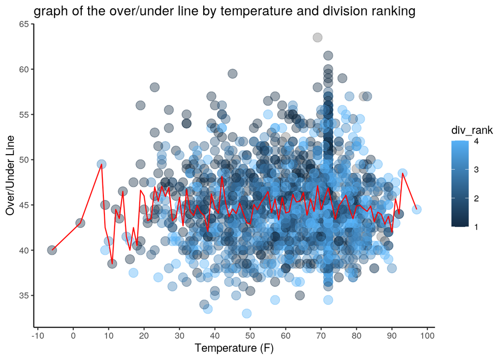

```r
plot1 <- ggplot(data = projectdatafinal, aes(x = weather_temperature,
    y = over_under_line, color = div_rank), ) + geom_point(size = 4,
    alpha = 0.4) + stat_summary(fun = mean, geom = "line", color = "red") +
    theme_classic() + scale_alpha_continuous() + scale_x_continuous(breaks = scales::pretty_breaks(n = 10)) +
    scale_y_continuous(breaks = scales::pretty_breaks(n = 10)) +
    labs(title = "graph of the over/under line by temperature and division ranking",
        x = "Temperature (F)", y = "Over/Under Line")

plot1
```

In this first plot I tried to see if there was a correlation between the weather and the line the oddsmaker take. I don’t see any correlation between these two as the red line shows the mean and it seems like most of the data is centered around the mean. I also made the color division rank to see if bad teams or good teams for that matter got different odds. The only thing I could see is that the most of the highest over/under line values were black meaning that the games that are predicted to score the most points are the ones where the best team in the division is playing.

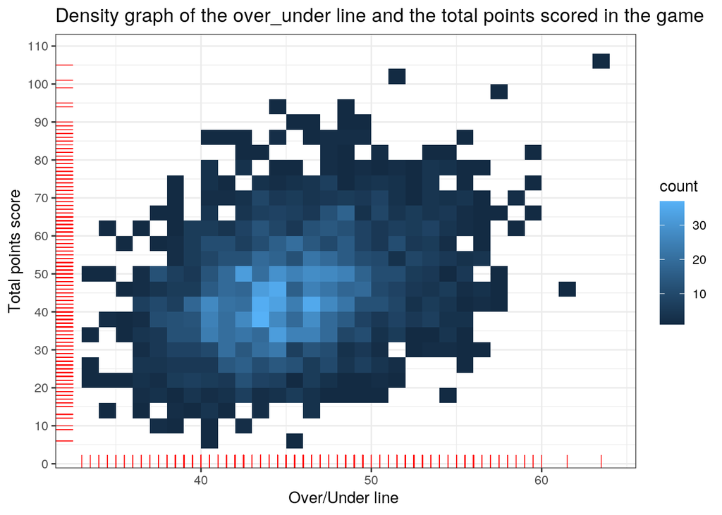

```r
plot2 <- ggplot(data = projectdatafinal, aes(x = over_under_line,
    y = over_under_lineTotal)) + geom_bin2d(binwidth = c(1, 4)) +
    theme_bw() + scale_alpha_continuous() + geom_rug(color = "red",
    size = 0.255, ) + labs(title = "Density graph of the over_under line and the total points scored in the game",
    x = "Over/Under line ", y = "Total points score") + scale_y_continuous(breaks = scales::pretty_breaks(n = 10))
plot2
```

In this plot I tried to get a feel for how most of the games ended up. In this graph we were able to see a large portion (blue area) finished with total points right around the line, This is good for Vegas as it makes it a virtually toss up. The geomrug() helps to follow up to find the point where people make money. If you bet the over of 50 all you have to do is follow the scores up from the x axis of 50 and as soon as you hit the 50 on the y axis anything above that is in the money!

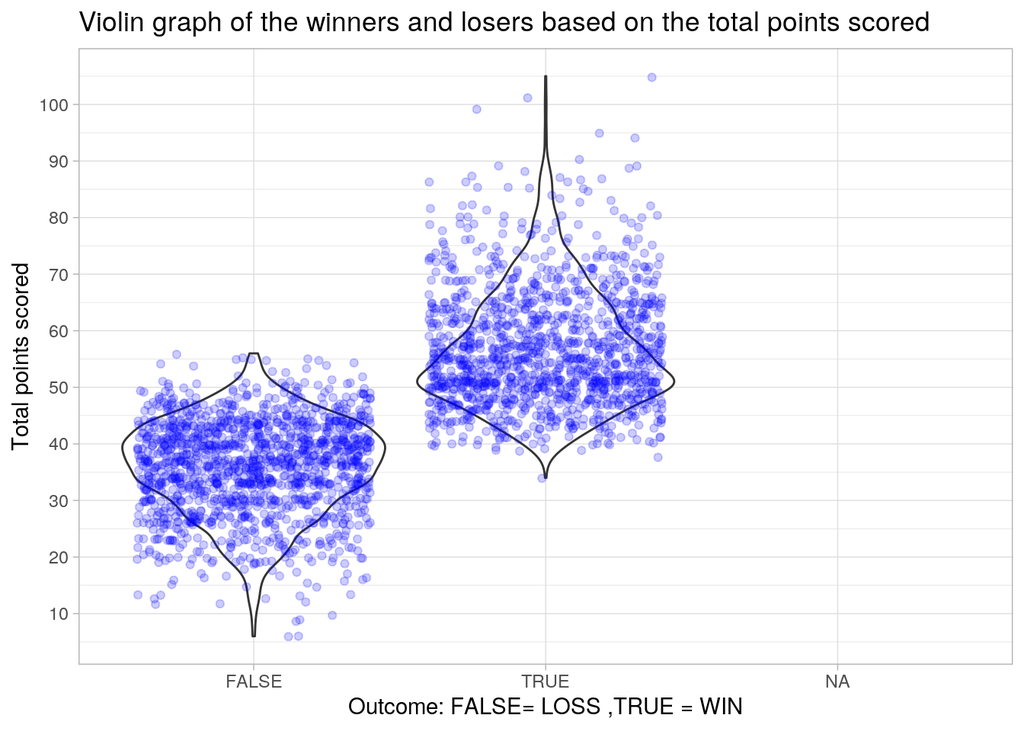

```r
plot3 <- ggplot(data = projectdatafinal, aes(x = over_under_lineWinorLose,
    y = over_under_lineTotal)) + geom_violin() + geom_jitter(color = "blue",
    alpha = 0.2) + theme_light() + scale_alpha_discrete() + labs(title = "Violin graph of the winners and losers based on the total points scored",
    x = "Outcome: FALSE= LOSS ,TRUE = WIN", y = "Total points scored") +
    scale_y_continuous(breaks = scales::pretty_breaks(n = 10))
plot3
```

This is my favorite plot I made, mostly because it is so scary, this graph show the spread of the total number of points for each of the outcomes of gambling a Win or a Loss. As you can see the big bulges in each of the graphs are very close to one another. This means that whatever number they put as the odds, The game is likely to be right around the score. This makes a virtual toss-up and essentially gambling because they are so good at their job. The scarier part of the graph is how thin the tails on the violin’s are. The odds they create can be really wrong, however it happens so frequently that no one would be able to use any type of statistic to their advantage.

#### Concluding Remarks

I had a couple other numerical variables but I did not really use those in any of my analysis so I did not create summary sheets for them. I feel like I ended up using everything that was asked of me it might not be in the right spot because I had to do lots of different things with my data. This project was tough but I really enjoyed it! Looking forward to part 2!